# Visualizing OPUS binary files in R

Adrianne Seiden

2026-07-21

# Overview

Use this markdown for quality control of OPUS binary files. It reads the files, extracts metadata (i.e. method parameters) and plots the spectra. It also stacks spectra for the same sample number, crop, and timepoint to check for consistency. Problematic spectra can be identified and then filtered out in DRIFTS_Camryn.Rmd.

# Reading OPUS files

[source](https://spectral-cockpit.github.io/opusreader2/articles/opusreader2_introduction.html)

This code is modified from the original OPUSreader2 documentation vignettes/opusreader2_introduction.Rmd by Philip Baumann and Thomas Knecht. It reads OPUS binary files and extracts metadata and absorbance data, which can then be plotted.

## Plots & Metadata

The main function, `read_opus()`, reads one or more OPUS files and returns a nested list of class `list_opusreader2`. Each list contains both the spectral data and metadata for each file. The `dsn` argument is the data source name. It can be a character vector of folder paths (to read files recursively) or specific OPUS file paths. Start by testing the read_opus function on your corrected spectra folder, and saving the output of the first file.

```r
#load opusreader2 from github.com/spectral-cockpit
library(opusreader2)

#save the path to your corrected spectra
# # Mac path
# corr_spectra <- "/Users/adrianneseiden/Library/CloudStorage/Box-Box/Salk Institute Project/AKS Salk files/Camryn_DRIFTSdata/corrected_data" # nolint
#  # Windows path
# corr_spectra <- "C:/Users/adria/Box/Box-Box/Salk Institute Project/AKS Salk files/Camryn_DRIFTSdata/corrected_data" # nolint
# # Relative path
# corr_spectra <- "../Camryn_DRIFTSdata/corrected_data"

#save the data from your corrected files as 'data_test'
data_test <- read_opus(dsn = corr_spectra)
#check the names of the list
names(data_test)
>  [1] "DRIFTS_Pot001_13Cwheat_wk0_rhizoSoil_260618_COR.0"
>  [2] "DRIFTS_Pot012_13Csoy_wk10_rhizoSoil_260624_COR.0"
>  [3] "DRIFTS_Pot020_12CnoPlant_wk30_rhizoSoil_260617_COR.0"
>  [4] "DRIFTS_Pot020_12CnoPlant_wk40_rhizoSoil_260617_COR.0"
>  [5] "DRIFTS_Pot024_13Cwheat_wk0_rhizoSoil_260618_COR.0"
>  [6] "DRIFTS_Pot028_13Cwheat_wk0_rhizoSoil_260618A_COR.0"
>  [7] "DRIFTS_Pot028_13Cwheat_wk0_rhizoSoil_260618B_COR.0"
>  [8] "DRIFTS_Pot029_13Cwheat_wk10_rhizoSoil_260624_COR.0"
>  [9] "DRIFTS_Pot029_13Cwheat_wk40_rhizoSoil_260702_COR.0"
> [10] "DRIFTS_Pot030_13Csoy_wk40_rhizoSoil_260702_COR.0"
> [11] "DRIFTS_Pot032_13Cwheat_wk0_rhizoSoil_260618_COR.0"
> [12] "DRIFTS_Pot044_13CnoPlant_wk0_bulkSoil_260617_COR.0"
> [13] "DRIFTS_Pot044_13CnoPlant_wk10_rhizoSoil_260617_COR.0"
> [14] "DRIFTS_Pot044_13CnoPlant_wk40_rhizoSoil_260617_COR.0"
> [15] "DRIFTS_Pot050_13Csoy_wk0_rhizoSoil_260618_COR.0"
> [16] "DRIFTS_Pot052_13CnoPlant_wk30_rhizoSoil_260617_COR.0"
> [17] "DRIFTS_Pot052_13CnoPlant_wk40_rhizoSoil_260617_COR.0"
> [18] "DRIFTS_Pot053_13Cwheat_wk10_rhizoSoil_260624_COR.0"
> [19] "DRIFTS_Pot053_13Cwheat_wk40_rhizoSoil_260702_COR.0"
> [20] "DRIFTS_Pot055_13Crice_wk10_rhizoSoil_260624A_COR.0"
> [21] "DRIFTS_Pot055_13Crice_wk10_rhizoSoil_260624B_COR.0"
> [22] "DRIFTS_Pot055_13Crice_wk40_rhizoSoil_260702_COR.0"
> [23] "DRIFTS_Pot062_13Csoy_wk0_rhizoSoil_260618_COR.0"
> [24] "DRIFTS_Pot064_13CnoPlant_wk0_bulkSoil_260617_COR.0"
> [25] "DRIFTS_Pot064_13CnoPlant_wk10_rhizoSoil_260617_COR.0"
> [26] "DRIFTS_Pot064_13CnoPlant_wk40_rhizoSoil_260617_COR.0"
> [27] "DRIFTS_Pot071_13Crice_wk0_rhizoSoil_260618A_COR.0"
> [28] "DRIFTS_Pot071_13Crice_wk0_rhizoSoil_260618B_COR.0"
> [29] "DRIFTS_Pot072_12CnoPlant_wk0_bulkSoil_260617_COR.0"
> [30] "DRIFTS_Pot072_12CnoPlant_wk10_rhizoSoil_260617_COR.0"
> [31] "DRIFTS_Pot072_12CnoPlant_wk10_rhizoSoil_260617a_COR.0"
> [32] "DRIFTS_Pot072_12CnoPlant_wk40_rhizoSoil_260617_COR.0"
> [33] "DRIFTS_Pot080_13Csoy_wk10_rhizoSoil_260624_COR.0"
> [34] "DRIFTS_Pot080_13Csoy_wk40_rhizoSoil_260702_COR.0"
> [35] "DRIFTS_Pot087_13Crice_wk10_rhizoSoil_260624_COR.0"
> [36] "DRIFTS_Pot087_13Crice_wk40_rhizoSoil_260702_COR.0"
> [37] "DRIFTS_Pot091_13CnoPlant_wk40_rhizoSoil_260617_COR.0"
> [38] "DRIFTS_Pot094_13Csoy_wk10_rhizoSoil_260624A_COR.0"
> [39] "DRIFTS_Pot094_13Csoy_wk10_rhizoSoil_260624B_COR.0"
> [40] "DRIFTS_Pot094_13Csoy_wk40_rhizoSoil_260702_COR.0"
> [41] "DRIFTS_Pot103_13Crice_wk0_rhizoSoil_260618_COR.0"
> [42] "DRIFTS_Pot104_13Csoy_wk0_rhizoSoil_260618_COR.0"
> [43] "DRIFTS_Pot108_12CnoPlant_wk40_rhizoSoil_260617_COR.0"
> [44] "DRIFTS_Pot109_13Cwheat_wk10_rhizoSoil_260624_COR.0"
> [45] "DRIFTS_Pot109_13Cwheat_wk10_rhizoSoil_260624a_COR.0"
> [46] "DRIFTS_Pot109_13Cwheat_wk40_rhizoSoil_260702_COR.0"
> [47] "DRIFTS_Pot119_13Crice_wk10_rhizoSoil_260624A_COR.0"
> [48] "DRIFTS_Pot119_13Crice_wk10_rhizoSoil_260624B_COR.0"
> [49] "DRIFTS_Pot119_13Crice_wk40_rhizoSoil_260702_COR.0"
# define 'meas_1' as the first element of the 'data_test' list
meas_1 <- data_test[[1]]
```

Next I defined a function, plotSpectrum, to plot the spectral data from a single sample (meas_1)

```r
# data is a list containing OPUS file data, including absorbance and metadata.

plotSpectrum <- function(data) { # nolint: object_name_linter.
  ab_data <- data$ab
  if (!is.null(ab_data) &&
        !is.null(ab_data$wavenumbers) && !is.null(ab_data$data) &&
        is.numeric(ab_data$wavenumbers) && is.numeric(ab_data$data) &&
        length(ab_data$wavenumbers) == length(ab_data$data) &&
        all(is.finite(ab_data$wavenumbers)) && all(is.finite(ab_data$data))) {
    plot(
      ab_data$wavenumbers, ab_data$data, type = "l",
      xlab = "Wavenumber (cm⁻¹)", ylab = "Absorbance",
      main = data$basic_metadata$dsn_filename,
      xlim = rev(range(ab_data$wavenumbers))
    )
  } else {
    cat("Absorbance data not found or not valid in this file.\n")
    str(ab_data)
  }
}
plotSpectrum(meas_1)
```

[output not shown]

To view all the available data categories, run ‘names(meas_1)’ in the console. To view the parameters within these categories use str(meas_1$category_name) where ‘category_name’ is ‘basic_metadata’, ‘optics’, etc.

The *plotMetadata* function combines the plot and table for a single spectrum.

```r
plotMetadata <- function(data) { # nolint: object_name_linter.
  plotSpectrum(data)
  metadataTable(data)
}
plotMetadata(meas_1)
```

[output not shown]

Metadata

| Parameter | Value |
| --- | --- |
| File Name | DRIFTS_Pot001_13Cwheat_wk0_rhizoSoil_260618_COR.0 |
| Timestamp | 2026-06-18 13:30:00 GMT-7 |
| Max Y | 0.869431912899017 |
| Min Y | -0.0147236697375774 |
| Aperture Setting | 4 mm |
| Scanner Velocity | 10.0S |
| Result Spectrum | AB |
| Resolution | 4 |
| Sample Scans | 400 |
| End Frequency | 400 |
| Start Frequency | 4000 |
| Duration | 364.490966796875 |
| Experiment (method) | SALK_soils_method.xpm |

### Combined plot and table (folder)

The following for loop runs plotMetadata on each spectrum in the data_test list, which contains all the spectra in the folder. It will plot each spectrum and print its metadata below.

```r
for (i in seq_along(data_test)) {
  cat("#### Spectrum", i, ":", names(data_test)[i], "\n\n")
  data_i <- data_test[[i]]
  ab_data <- data_i$ab
  valid <- !is.null(ab_data) &&
    !is.null(ab_data$wavenumbers) && !is.null(ab_data$data) &&
    is.numeric(ab_data$wavenumbers) && is.numeric(ab_data$data) &&
    length(ab_data$wavenumbers) == length(ab_data$data) &&
    all(is.finite(ab_data$wavenumbers)) && all(is.finite(ab_data$data))
  if (valid) {
    plotSpectrum(data_i)
    print(metadataTable(data_i))
  } else {
    cat("Data not valid or missing for this spectrum.\n")
    str(ab_data)
  }
}
```

[output not shown]

#### Spectrum 1 : DRIFTS_Pot001_13Cwheat_wk0_rhizoSoil_260618_COR.0

Metadata

| Parameter | Value |
| --- | --- |
| File Name | DRIFTS_Pot001_13Cwheat_wk0_rhizoSoil_260618_COR.0 |
| Timestamp | 2026-06-18 13:30:00 GMT-7 |
| Max Y | 0.869431912899017 |
| Min Y | -0.0147236697375774 |
| Aperture Setting | 4 mm |
| Scanner Velocity | 10.0S |
| Result Spectrum | AB |
| Resolution | 4 |
| Sample Scans | 400 |
| End Frequency | 400 |
| Start Frequency | 4000 |
| Duration | 364.490966796875 |
| Experiment (method) | SALK_soils_method.xpm |

#### Spectrum 2 : DRIFTS_Pot012_13Csoy_wk10_rhizoSoil_260624_COR.0

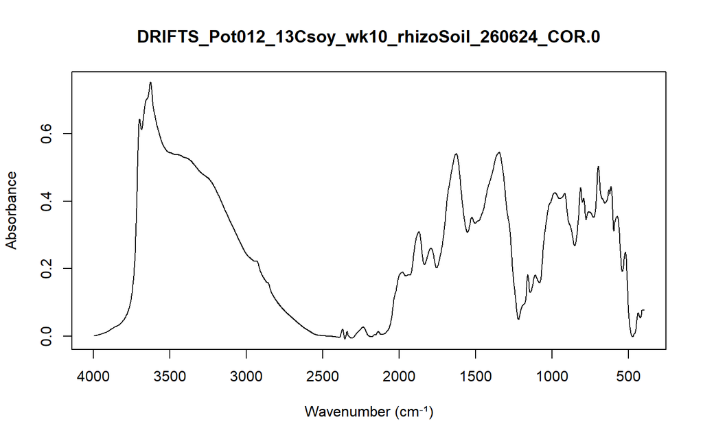

Metadata

| Parameter | Value |
| --- | --- |
| File Name | DRIFTS_Pot012_13Csoy_wk10_rhizoSoil_260624_COR.0 |
| Timestamp | 2026-06-24 16:31:29 GMT-7 |
| Max Y | 0.753294765949249 |
| Min Y | -0.00849825888872147 |
| Aperture Setting | 4 mm |
| Scanner Velocity | 10.0S |
| Result Spectrum | AB |
| Resolution | 4 |
| Sample Scans | 400 |
| End Frequency | 400 |
| Start Frequency | 4000 |
| Duration | 364.48583984375 |
| Experiment (method) | SALK_soils_method.xpm |

#### Spectrum 3 : DRIFTS_Pot020_12CnoPlant_wk30_rhizoSoil_260617_COR.0

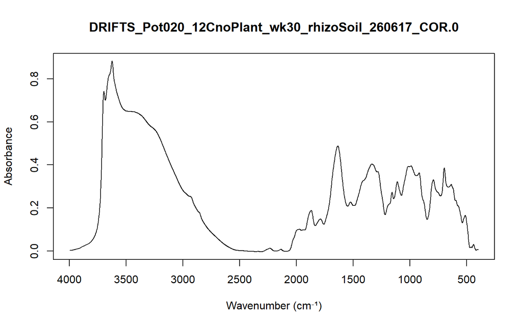

Metadata

| Parameter | Value |
| --- | --- |
| File Name | DRIFTS_Pot020_12CnoPlant_wk30_rhizoSoil_260617_COR.0 |
| Timestamp | 2026-06-17 13:41:46 GMT-7 |
| Max Y | 0.883588850498199 |
| Min Y | -0.00407580798491836 |
| Aperture Setting | 4 mm |
| Scanner Velocity | 10.0S |
| Result Spectrum | AB |
| Resolution | 4 |
| Sample Scans | 400 |
| End Frequency | 400 |
| Start Frequency | 4000 |
| Duration | 364.48779296875 |
| Experiment (method) | SALK_soils_method.xpm |

#### Spectrum 4 : DRIFTS_Pot020_12CnoPlant_wk40_rhizoSoil_260617_COR.0

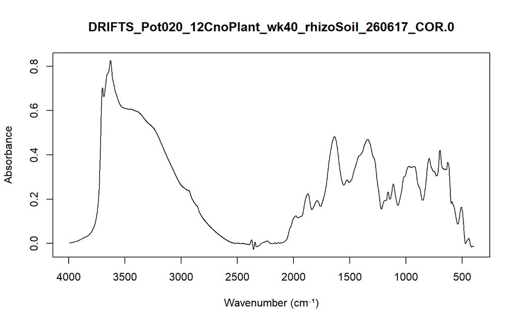

Metadata

| Parameter | Value |
| --- | --- |
| File Name | DRIFTS_Pot020_12CnoPlant_wk40_rhizoSoil_260617_COR.0 |
| Timestamp | 2026-06-17 13:42:19 GMT-7 |
| Max Y | 0.826479434967041 |
| Min Y | -0.0271399822086096 |
| Aperture Setting | 4 mm |
| Scanner Velocity | 10.0S |
| Result Spectrum | AB |
| Resolution | 4 |
| Sample Scans | 400 |
| End Frequency | 400 |
| Start Frequency | 4000 |
| Duration | 364.495849609375 |
| Experiment (method) | SALK_soils_method.xpm |

#### Spectrum 5 : DRIFTS_Pot024_13Cwheat_wk0_rhizoSoil_260618_COR.0

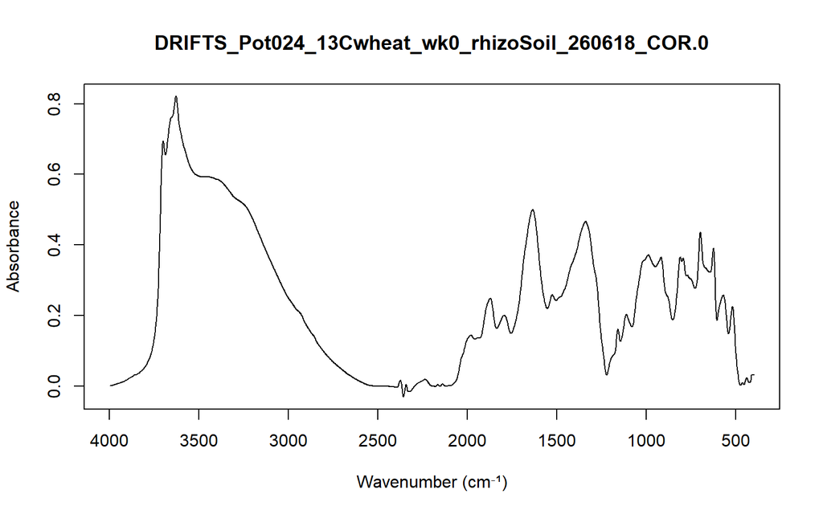

Metadata

| Parameter | Value |
| --- | --- |
| File Name | DRIFTS_Pot024_13Cwheat_wk0_rhizoSoil_260618_COR.0 |
| Timestamp | 2026-06-18 13:30:15 GMT-7 |
| Max Y | 0.821595847606659 |
| Min Y | -0.0310575272887945 |
| Aperture Setting | 4 mm |
| Scanner Velocity | 10.0S |
| Result Spectrum | AB |
| Resolution | 4 |
| Sample Scans | 400 |
| End Frequency | 400 |
| Start Frequency | 4000 |
| Duration | 364.5068359375 |
| Experiment (method) | SALK_soils_method.xpm |

#### Spectrum 6 : DRIFTS_Pot028_13Cwheat_wk0_rhizoSoil_260618A_COR.0

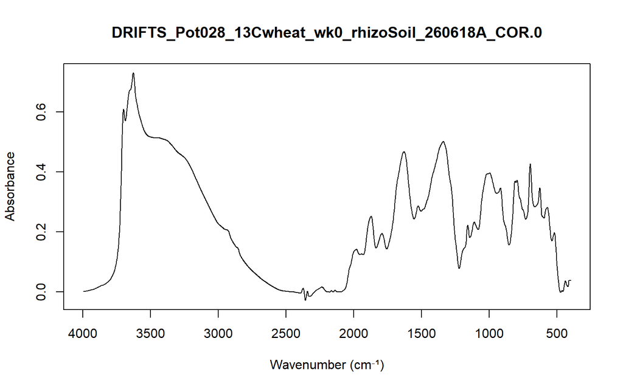

Metadata

| Parameter | Value |
| --- | --- |
| File Name | DRIFTS_Pot028_13Cwheat_wk0_rhizoSoil_260618A_COR.0 |
| Timestamp | 2026-06-18 13:30:27 GMT-7 |
| Max Y | 0.730432510375977 |
| Min Y | -0.0288395490497351 |
| Aperture Setting | 4 mm |
| Scanner Velocity | 10.0S |
| Result Spectrum | AB |
| Resolution | 4 |
| Sample Scans | 400 |
| End Frequency | 400 |
| Start Frequency | 4000 |
| Duration | 364.476806640625 |
| Experiment (method) | SALK_soils_method.xpm |

#### Spectrum 7 : DRIFTS_Pot028_13Cwheat_wk0_rhizoSoil_260618B_COR.0

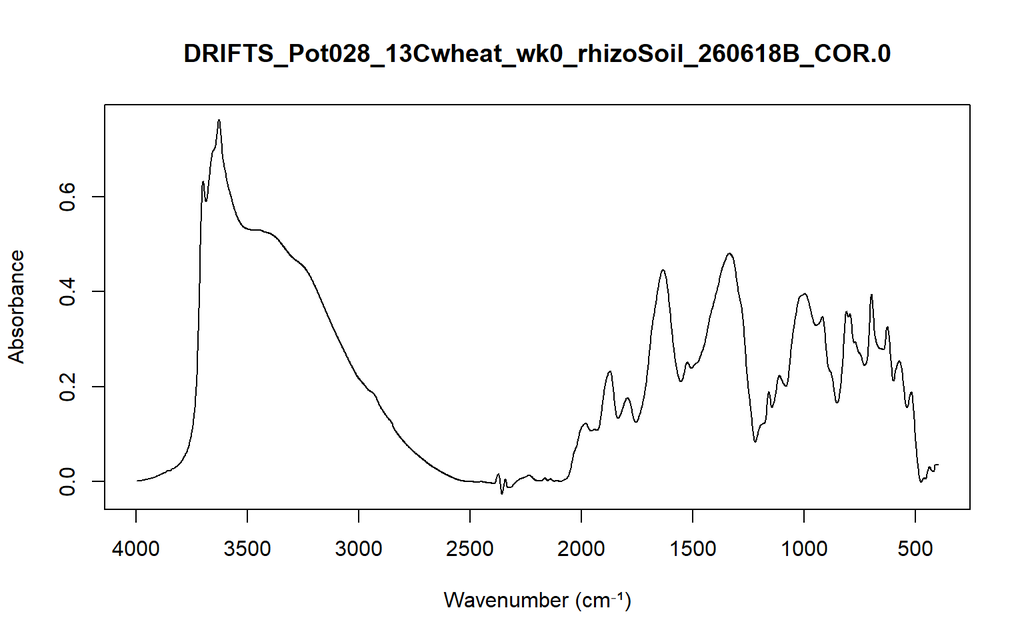

Metadata

| Parameter | Value |
| --- | --- |
| File Name | DRIFTS_Pot028_13Cwheat_wk0_rhizoSoil_260618B_COR.0 |
| Timestamp | 2026-06-18 13:30:40 GMT-7 |
| Max Y | 0.761946260929108 |
| Min Y | -0.0266887731850147 |
| Aperture Setting | 4 mm |
| Scanner Velocity | 10.0S |
| Result Spectrum | AB |
| Resolution | 4 |
| Sample Scans | 400 |
| End Frequency | 400 |
| Start Frequency | 4000 |
| Duration | 364.48779296875 |
| Experiment (method) | SALK_soils_method.xpm |

#### Spectrum 8 : DRIFTS_Pot029_13Cwheat_wk10_rhizoSoil_260624_COR.0

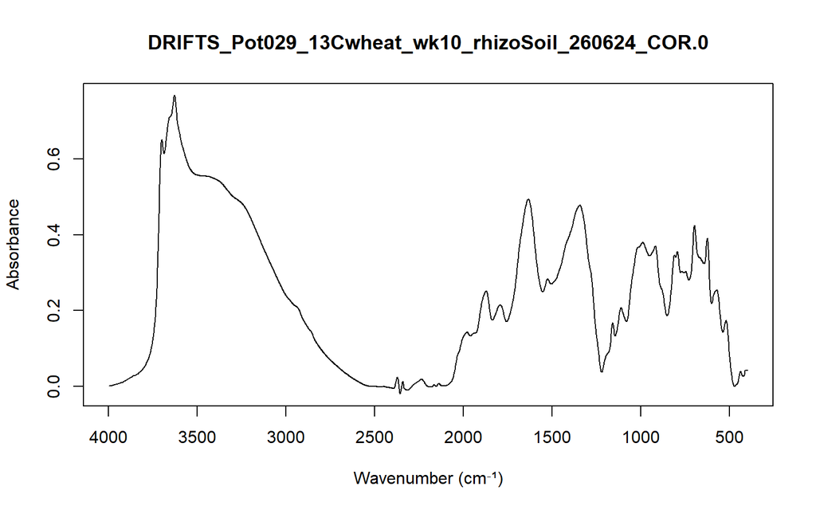

Metadata

| Parameter | Value |
| --- | --- |
| File Name | DRIFTS_Pot029_13Cwheat_wk10_rhizoSoil_260624_COR.0 |
| Timestamp | 2026-06-24 16:31:43 GMT-7 |
| Max Y | 0.767195582389832 |
| Min Y | -0.0195840522646904 |
| Aperture Setting | 4 mm |
| Scanner Velocity | 10.0S |
| Result Spectrum | AB |
| Resolution | 4 |
| Sample Scans | 400 |
| End Frequency | 400 |
| Start Frequency | 4000 |
| Duration | 364.493896484375 |
| Experiment (method) | SALK_soils_method.xpm |

#### Spectrum 9 : DRIFTS_Pot029_13Cwheat_wk40_rhizoSoil_260702_COR.0

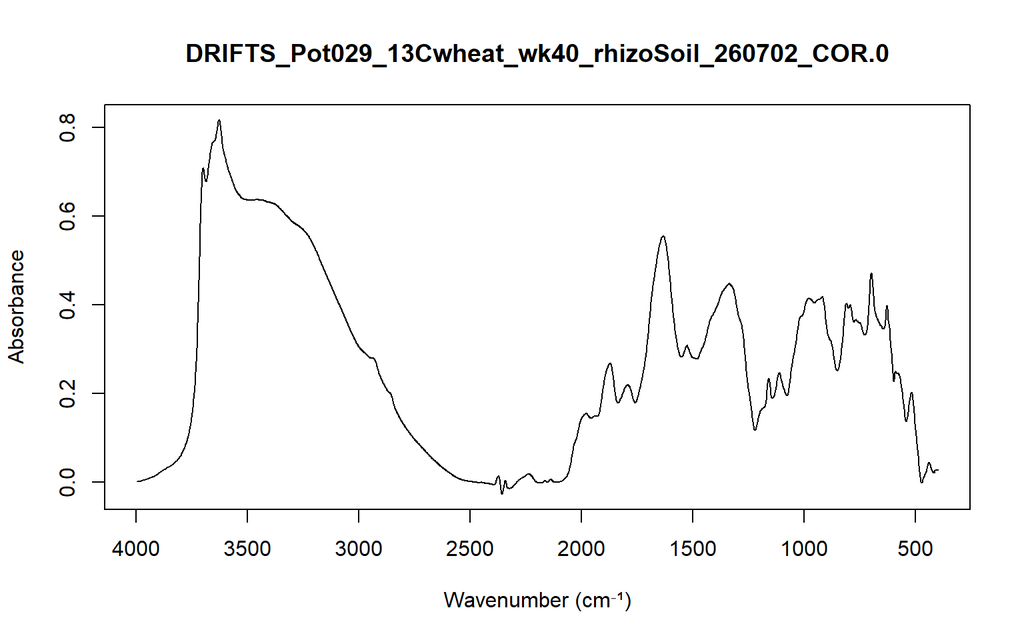

Metadata

| Parameter | Value |
| --- | --- |
| File Name | DRIFTS_Pot029_13Cwheat_wk40_rhizoSoil_260702_COR.0 |
| Timestamp | 2026-07-02 13:45:48 GMT-7 |
| Max Y | 0.817450702190399 |
| Min Y | -0.0266631823033094 |
| Aperture Setting | 4 mm |
| Scanner Velocity | 10.0S |
| Result Spectrum | AB |
| Resolution | 4 |
| Sample Scans | 400 |
| End Frequency | 400 |
| Start Frequency | 4000 |
| Duration | 364.450927734375 |
| Experiment (method) | SALK_soils_method.xpm |

#### Spectrum 10 : DRIFTS_Pot030_13Csoy_wk40_rhizoSoil_260702_COR.0

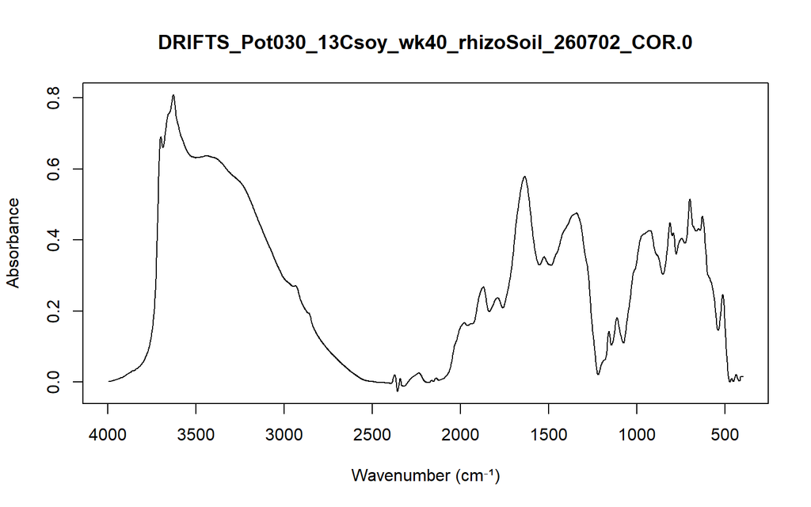

Metadata

| Parameter | Value |
| --- | --- |
| File Name | DRIFTS_Pot030_13Csoy_wk40_rhizoSoil_260702_COR.0 |
| Timestamp | 2026-07-02 13:46:05 GMT-7 |
| Max Y | 0.808740079402924 |
| Min Y | -0.0264372732490301 |
| Aperture Setting | 4 mm |
| Scanner Velocity | 10.0S |
| Result Spectrum | AB |
| Resolution | 4 |
| Sample Scans | 400 |
| End Frequency | 400 |
| Start Frequency | 4000 |
| Duration | 364.44091796875 |
| Experiment (method) | SALK_soils_method.xpm |

#### Spectrum 11 : DRIFTS_Pot032_13Cwheat_wk0_rhizoSoil_260618_COR.0

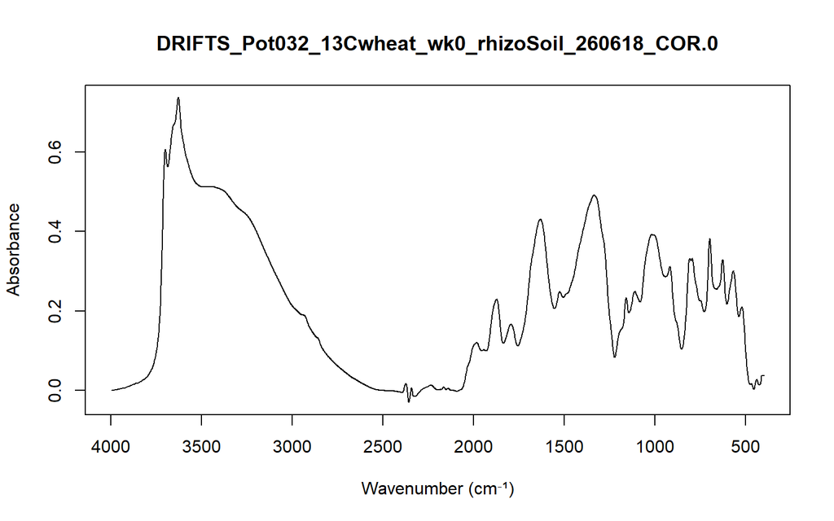

Metadata

| Parameter | Value |
| --- | --- |
| File Name | DRIFTS_Pot032_13Cwheat_wk0_rhizoSoil_260618_COR.0 |
| Timestamp | 2026-06-18 13:30:52 GMT-7 |
| Max Y | 0.737250328063965 |
| Min Y | -0.0297119431197643 |
| Aperture Setting | 4 mm |
| Scanner Velocity | 10.0S |
| Result Spectrum | AB |
| Resolution | 4 |
| Sample Scans | 400 |
| End Frequency | 400 |
| Start Frequency | 4000 |
| Duration | 364.478759765625 |
| Experiment (method) | SALK_soils_method.xpm |

#### Spectrum 12 : DRIFTS_Pot044_13CnoPlant_wk0_bulkSoil_260617_COR.0

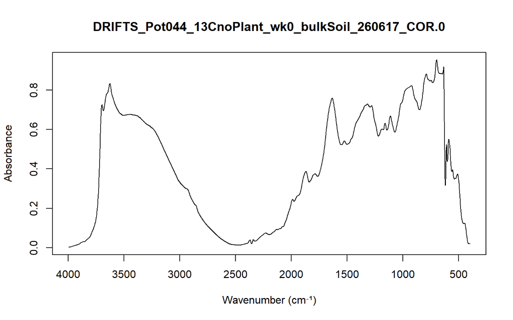

Metadata

| Parameter | Value |
| --- | --- |
| File Name | DRIFTS_Pot044_13CnoPlant_wk0_bulkSoil_260617_COR.0 |
| Timestamp | 2026-06-17 17:12:55 GMT-7 |
| Max Y | 0.952217578887939 |
| Min Y | 0.0031768826302141 |
| Aperture Setting | 4 mm |
| Scanner Velocity | 10.0S |
| Result Spectrum | AB |
| Resolution | 4 |
| Sample Scans | 400 |
| End Frequency | 400 |
| Start Frequency | 4000 |
| Duration | 364.48876953125 |
| Experiment (method) | SALK_soils_method.xpm |

#### Spectrum 13 : DRIFTS_Pot044_13CnoPlant_wk10_rhizoSoil_260617_COR.0

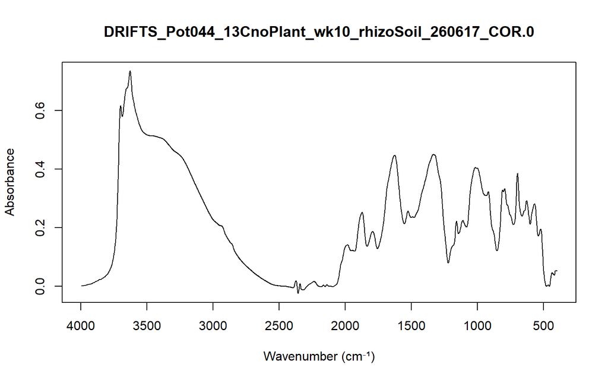

Metadata

| Parameter | Value |
| --- | --- |
| File Name | DRIFTS_Pot044_13CnoPlant_wk10_rhizoSoil_260617_COR.0 |
| Timestamp | 2026-06-17 17:13:18 GMT-7 |
| Max Y | 0.735088109970093 |
| Min Y | -0.0245311800390482 |
| Aperture Setting | 4 mm |
| Scanner Velocity | 10.0S |
| Result Spectrum | AB |
| Resolution | 4 |
| Sample Scans | 400 |
| End Frequency | 400 |
| Start Frequency | 4000 |
| Duration | 364.489990234375 |
| Experiment (method) | SALK_soils_method.xpm |

#### Spectrum 14 : DRIFTS_Pot044_13CnoPlant_wk40_rhizoSoil_260617_COR.0

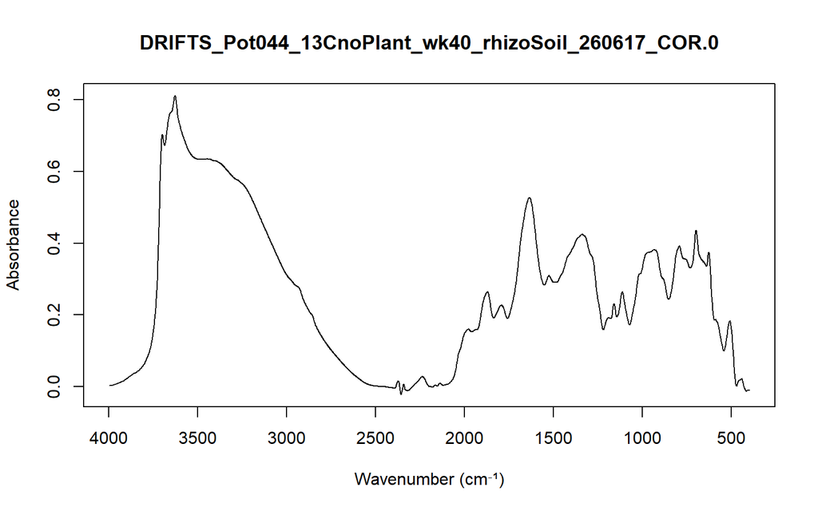

Metadata

| Parameter | Value |
| --- | --- |
| File Name | DRIFTS_Pot044_13CnoPlant_wk40_rhizoSoil_260617_COR.0 |
| Timestamp | 2026-06-17 17:13:30 GMT-7 |
| Max Y | 0.81170392036438 |
| Min Y | -0.0225546676665545 |
| Aperture Setting | 4 mm |
| Scanner Velocity | 10.0S |
| Result Spectrum | AB |
| Resolution | 4 |
| Sample Scans | 400 |
| End Frequency | 400 |
| Start Frequency | 4000 |
| Duration | 364.5048828125 |
| Experiment (method) | SALK_soils_method.xpm |

#### Spectrum 15 : DRIFTS_Pot050_13Csoy_wk0_rhizoSoil_260618_COR.0

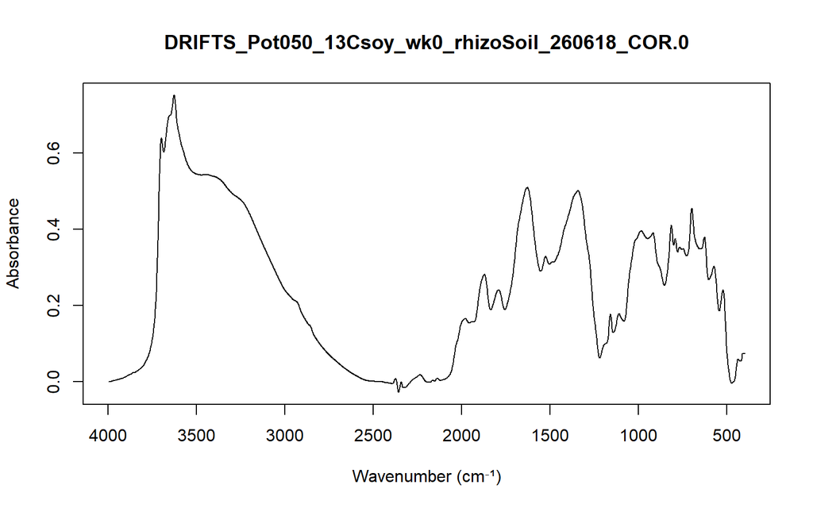

Metadata

| Parameter | Value |
| --- | --- |
| File Name | DRIFTS_Pot050_13Csoy_wk0_rhizoSoil_260618_COR.0 |
| Timestamp | 2026-06-18 13:31:08 GMT-7 |
| Max Y | 0.75178462266922 |
| Min Y | -0.0275299791246653 |
| Aperture Setting | 4 mm |
| Scanner Velocity | 10.0S |
| Result Spectrum | AB |
| Resolution | 4 |
| Sample Scans | 400 |
| End Frequency | 400 |
| Start Frequency | 4000 |
| Duration | 364.5078125 |
| Experiment (method) | SALK_soils_method.xpm |

#### Spectrum 16 : DRIFTS_Pot052_13CnoPlant_wk30_rhizoSoil_260617_COR.0

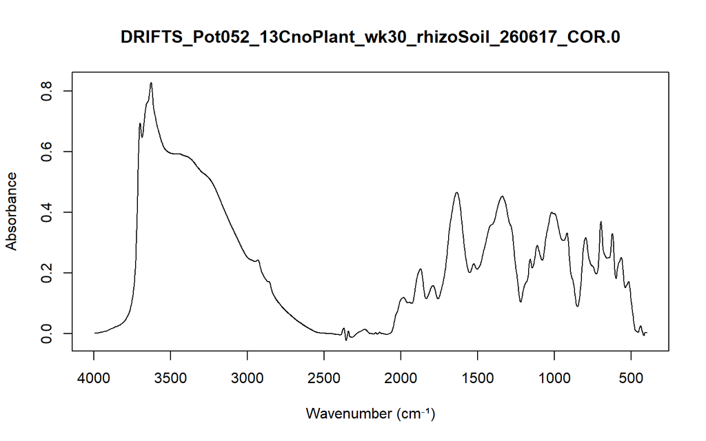

Metadata

| Parameter | Value |
| --- | --- |
| File Name | DRIFTS_Pot052_13CnoPlant_wk30_rhizoSoil_260617_COR.0 |
| Timestamp | 2026-06-17 17:13:44 GMT-7 |
| Max Y | 0.827746570110321 |
| Min Y | -0.02271175570786 |
| Aperture Setting | 4 mm |
| Scanner Velocity | 10.0S |
| Result Spectrum | AB |
| Resolution | 4 |
| Sample Scans | 400 |
| End Frequency | 400 |
| Start Frequency | 4000 |
| Duration | 364.48095703125 |
| Experiment (method) | SALK_soils_method.xpm |

#### Spectrum 17 : DRIFTS_Pot052_13CnoPlant_wk40_rhizoSoil_260617_COR.0

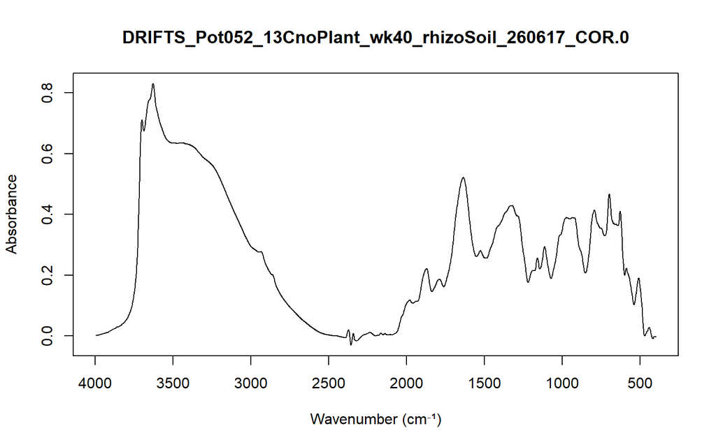

Metadata

| Parameter | Value |
| --- | --- |
| File Name | DRIFTS_Pot052_13CnoPlant_wk40_rhizoSoil_260617_COR.0 |
| Timestamp | 2026-06-17 17:13:58 GMT-7 |
| Max Y | 0.83060610294342 |
| Min Y | -0.0310649368911982 |
| Aperture Setting | 4 mm |
| Scanner Velocity | 10.0S |
| Result Spectrum | AB |
| Resolution | 4 |
| Sample Scans | 400 |
| End Frequency | 400 |
| Start Frequency | 4000 |
| Duration | 364.476806640625 |
| Experiment (method) | SALK_soils_method.xpm |

#### Spectrum 18 : DRIFTS_Pot053_13Cwheat_wk10_rhizoSoil_260624_COR.0

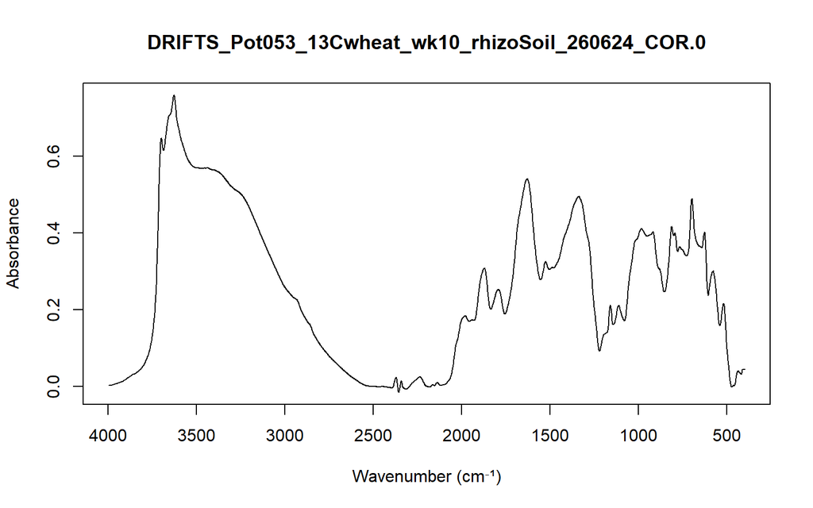

Metadata

| Parameter | Value |
| --- | --- |
| File Name | DRIFTS_Pot053_13Cwheat_wk10_rhizoSoil_260624_COR.0 |
| Timestamp | 2026-06-24 16:31:56 GMT-7 |
| Max Y | 0.758794665336609 |
| Min Y | -0.0154863903298974 |
| Aperture Setting | 4 mm |
| Scanner Velocity | 10.0S |
| Result Spectrum | AB |
| Resolution | 4 |
| Sample Scans | 400 |
| End Frequency | 400 |
| Start Frequency | 4000 |
| Duration | 364.492919921875 |
| Experiment (method) | SALK_soils_method.xpm |

#### Spectrum 19 : DRIFTS_Pot053_13Cwheat_wk40_rhizoSoil_260702_COR.0

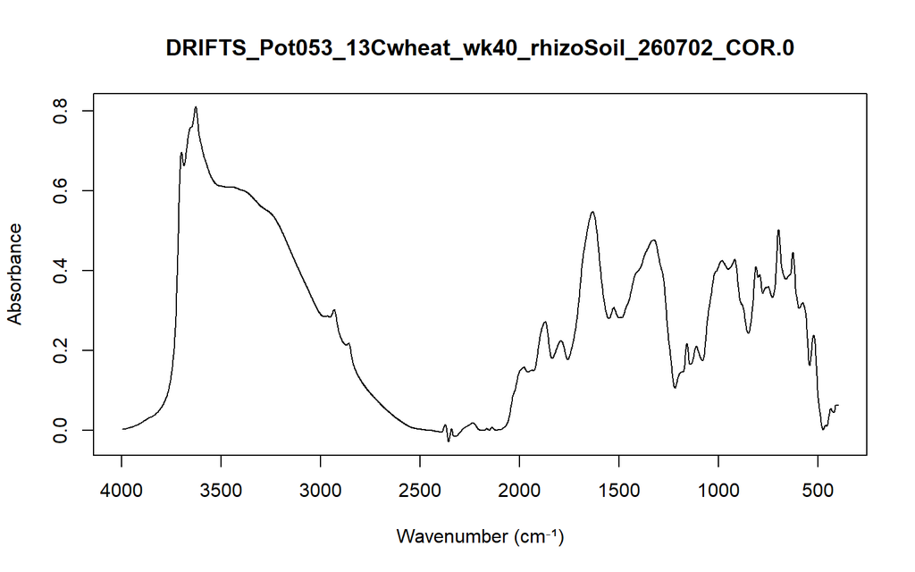

Metadata

| Parameter | Value |
| --- | --- |
| File Name | DRIFTS_Pot053_13Cwheat_wk40_rhizoSoil_260702_COR.0 |
| Timestamp | 2026-07-02 13:46:16 GMT-7 |
| Max Y | 0.809180915355682 |
| Min Y | -0.0292344819754362 |
| Aperture Setting | 4 mm |
| Scanner Velocity | 10.0S |
| Result Spectrum | AB |
| Resolution | 4 |
| Sample Scans | 400 |
| End Frequency | 400 |
| Start Frequency | 4000 |
| Duration | 364.454833984375 |
| Experiment (method) | SALK_soils_method.xpm |

#### Spectrum 20 : DRIFTS_Pot055_13Crice_wk10_rhizoSoil_260624A_COR.0

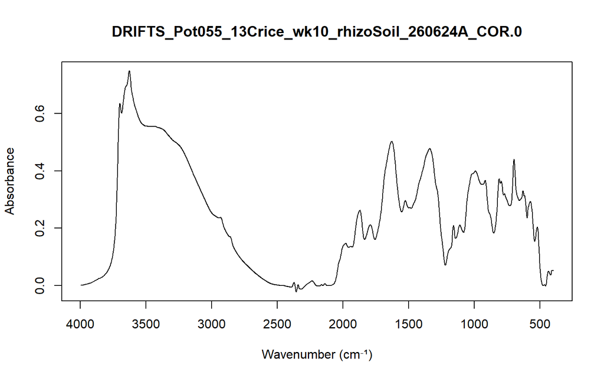

Metadata

| Parameter | Value |
| --- | --- |
| File Name | DRIFTS_Pot055_13Crice_wk10_rhizoSoil_260624A_COR.0 |
| Timestamp | 2026-06-24 16:32:13 GMT-7 |
| Max Y | 0.748376727104187 |
| Min Y | -0.0217512603849173 |
| Aperture Setting | 4 mm |
| Scanner Velocity | 10.0S |
| Result Spectrum | AB |
| Resolution | 4 |
| Sample Scans | 400 |
| End Frequency | 400 |
| Start Frequency | 4000 |
| Duration | 364.497802734375 |
| Experiment (method) | SALK_soils_method.xpm |

#### Spectrum 21 : DRIFTS_Pot055_13Crice_wk10_rhizoSoil_260624B_COR.0

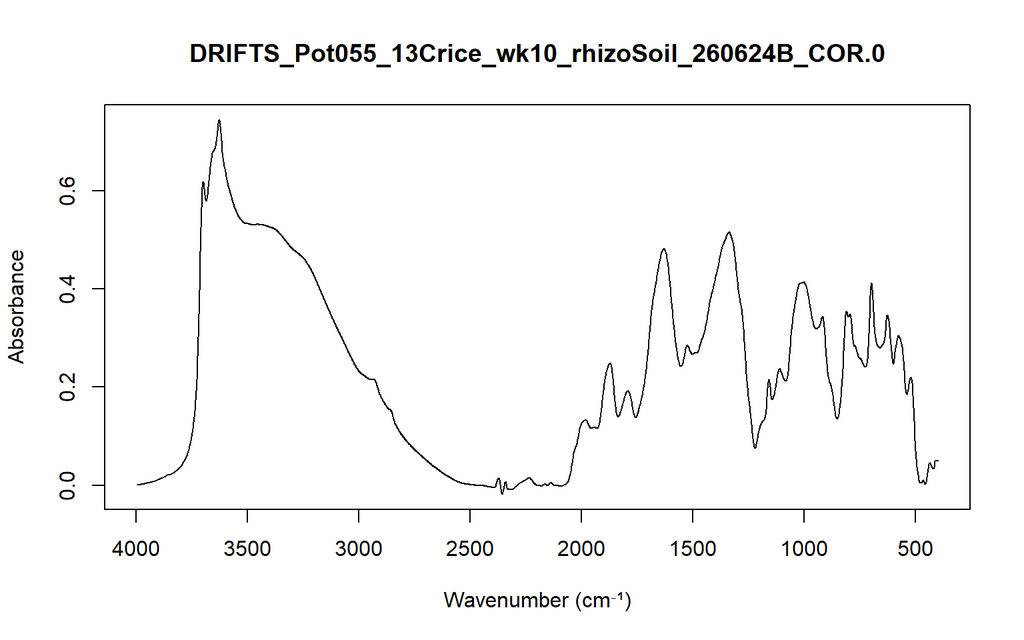

Metadata

| Parameter | Value |
| --- | --- |
| File Name | DRIFTS_Pot055_13Crice_wk10_rhizoSoil_260624B_COR.0 |
| Timestamp | 2026-06-24 16:32:34 GMT-7 |
| Max Y | 0.744171261787415 |
| Min Y | -0.0181926600635052 |
| Aperture Setting | 4 mm |
| Scanner Velocity | 10.0S |
| Result Spectrum | AB |
| Resolution | 4 |
| Sample Scans | 400 |
| End Frequency | 400 |
| Start Frequency | 4000 |
| Duration | 364.490966796875 |
| Experiment (method) | SALK_soils_method.xpm |

#### Spectrum 22 : DRIFTS_Pot055_13Crice_wk40_rhizoSoil_260702_COR.0

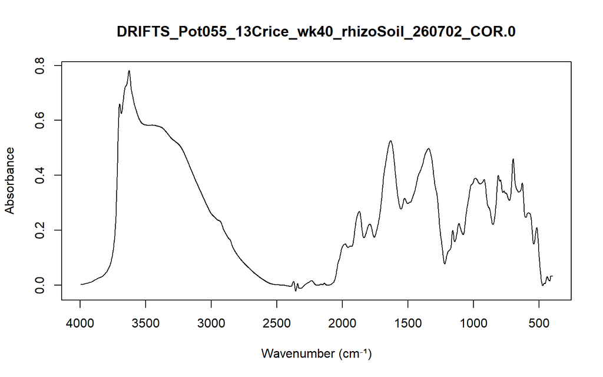

Metadata

| Parameter | Value |
| --- | --- |
| File Name | DRIFTS_Pot055_13Crice_wk40_rhizoSoil_260702_COR.0 |
| Timestamp | 2026-07-02 13:46:30 GMT-7 |
| Max Y | 0.781714081764221 |
| Min Y | -0.0220434293150902 |
| Aperture Setting | 4 mm |
| Scanner Velocity | 10.0S |
| Result Spectrum | AB |
| Resolution | 4 |
| Sample Scans | 400 |
| End Frequency | 400 |
| Start Frequency | 4000 |
| Duration | 364.435791015625 |
| Experiment (method) | SALK_soils_method.xpm |

#### Spectrum 23 : DRIFTS_Pot062_13Csoy_wk0_rhizoSoil_260618_COR.0

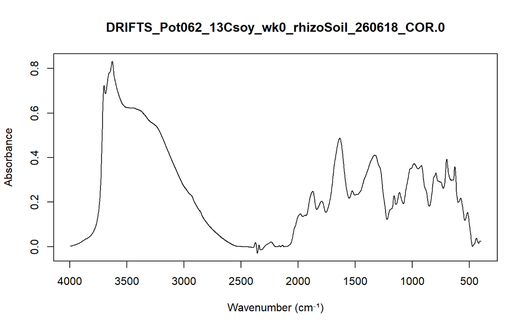

Metadata

| Parameter | Value |
| --- | --- |
| File Name | DRIFTS_Pot062_13Csoy_wk0_rhizoSoil_260618_COR.0 |
| Timestamp | 2026-06-18 13:31:33 GMT-7 |
| Max Y | 0.832091510295868 |
| Min Y | -0.0301933344453573 |
| Aperture Setting | 4 mm |
| Scanner Velocity | 10.0S |
| Result Spectrum | AB |
| Resolution | 4 |
| Sample Scans | 400 |
| End Frequency | 400 |
| Start Frequency | 4000 |
| Duration | 364.48095703125 |
| Experiment (method) | SALK_soils_method.xpm |

#### Spectrum 24 : DRIFTS_Pot064_13CnoPlant_wk0_bulkSoil_260617_COR.0

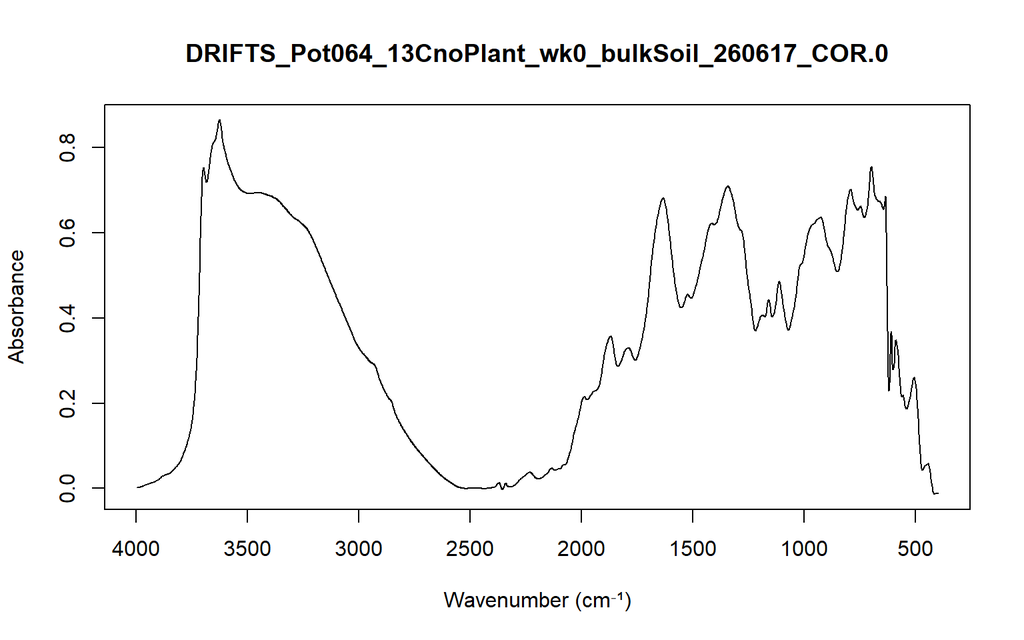

Metadata

| Parameter | Value |
| --- | --- |
| File Name | DRIFTS_Pot064_13CnoPlant_wk0_bulkSoil_260617_COR.0 |
| Timestamp | 2026-06-17 17:14:13 GMT-7 |
| Max Y | 0.865809559822083 |
| Min Y | -0.0137597797438502 |
| Aperture Setting | 4 mm |
| Scanner Velocity | 10.0S |
| Result Spectrum | AB |
| Resolution | 4 |
| Sample Scans | 400 |
| End Frequency | 400 |
| Start Frequency | 4000 |
| Duration | 364.469970703125 |
| Experiment (method) | SALK_soils_method.xpm |

#### Spectrum 25 : DRIFTS_Pot064_13CnoPlant_wk10_rhizoSoil_260617_COR.0

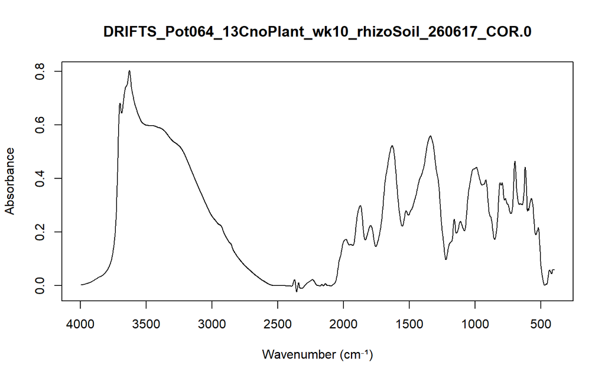

Metadata

| Parameter | Value |
| --- | --- |
| File Name | DRIFTS_Pot064_13CnoPlant_wk10_rhizoSoil_260617_COR.0 |
| Timestamp | 2026-06-17 17:14:27 GMT-7 |
| Max Y | 0.802513480186462 |
| Min Y | -0.0236224569380283 |
| Aperture Setting | 4 mm |
| Scanner Velocity | 10.0S |
| Result Spectrum | AB |
| Resolution | 4 |
| Sample Scans | 400 |
| End Frequency | 400 |
| Start Frequency | 4000 |
| Duration | 364.475830078125 |
| Experiment (method) | SALK_soils_method.xpm |

#### Spectrum 26 : DRIFTS_Pot064_13CnoPlant_wk40_rhizoSoil_260617_COR.0

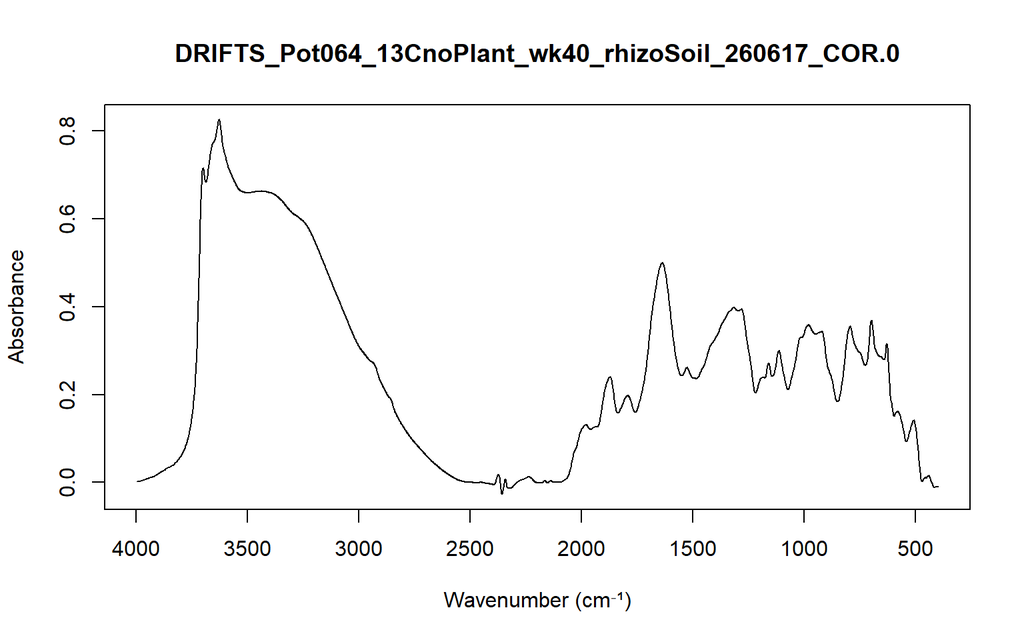

Metadata

| Parameter | Value |
| --- | --- |
| File Name | DRIFTS_Pot064_13CnoPlant_wk40_rhizoSoil_260617_COR.0 |
| Timestamp | 2026-06-17 17:14:42 GMT-7 |
| Max Y | 0.825817108154297 |
| Min Y | -0.0272186957299709 |
| Aperture Setting | 4 mm |
| Scanner Velocity | 10.0S |
| Result Spectrum | AB |
| Resolution | 4 |
| Sample Scans | 400 |
| End Frequency | 400 |
| Start Frequency | 4000 |
| Duration | 364.47998046875 |
| Experiment (method) | SALK_soils_method.xpm |

#### Spectrum 27 : DRIFTS_Pot071_13Crice_wk0_rhizoSoil_260618A_COR.0

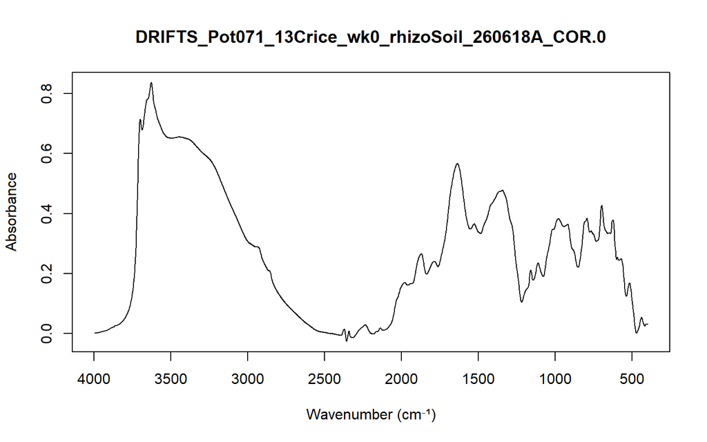

Metadata

| Parameter | Value |
| --- | --- |
| File Name | DRIFTS_Pot071_13Crice_wk0_rhizoSoil_260618A_COR.0 |
| Timestamp | 2026-06-18 13:31:48 GMT-7 |
| Max Y | 0.836202681064606 |
| Min Y | -0.0258680414408445 |
| Aperture Setting | 4 mm |
| Scanner Velocity | 10.0S |
| Result Spectrum | AB |
| Resolution | 4 |
| Sample Scans | 400 |
| End Frequency | 400 |
| Start Frequency | 4000 |
| Duration | 364.494873046875 |
| Experiment (method) | SALK_soils_method.xpm |

#### Spectrum 28 : DRIFTS_Pot071_13Crice_wk0_rhizoSoil_260618B_COR.0

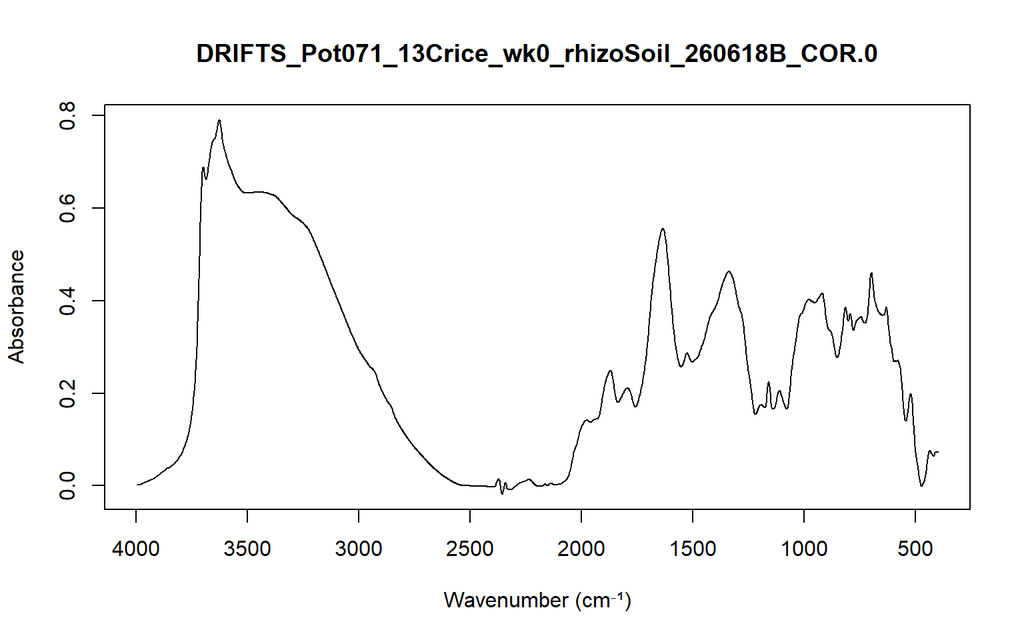

Metadata

| Parameter | Value |
| --- | --- |
| File Name | DRIFTS_Pot071_13Crice_wk0_rhizoSoil_260618B_COR.0 |
| Timestamp | 2026-06-18 13:31:59 GMT-7 |
| Max Y | 0.791451871395111 |
| Min Y | -0.0183036495000124 |
| Aperture Setting | 4 mm |
| Scanner Velocity | 10.0S |
| Result Spectrum | AB |
| Resolution | 4 |
| Sample Scans | 400 |
| End Frequency | 400 |
| Start Frequency | 4000 |
| Duration | 364.501953125 |
| Experiment (method) | SALK_soils_method.xpm |

#### Spectrum 29 : DRIFTS_Pot072_12CnoPlant_wk0_bulkSoil_260617_COR.0

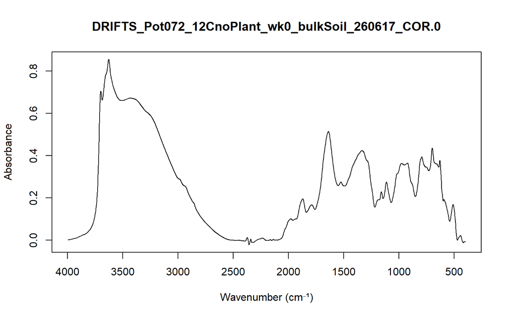

Metadata

| Parameter | Value |
| --- | --- |
| File Name | DRIFTS_Pot072_12CnoPlant_wk0_bulkSoil_260617_COR.0 |
| Timestamp | 2026-06-17 13:43:25 GMT-7 |
| Max Y | 0.854816257953644 |
| Min Y | -0.0216473862528801 |
| Aperture Setting | 4 mm |
| Scanner Velocity | 10.0S |
| Result Spectrum | AB |
| Resolution | 4 |
| Sample Scans | 400 |
| End Frequency | 400 |
| Start Frequency | 4000 |
| Duration | 364.477783203125 |
| Experiment (method) | SALK_soils_method.xpm |

#### Spectrum 30 : DRIFTS_Pot072_12CnoPlant_wk10_rhizoSoil_260617_COR.0

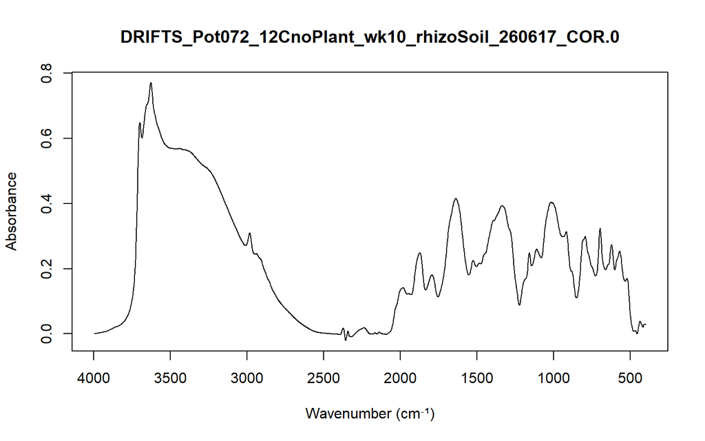

Metadata

| Parameter | Value |
| --- | --- |
| File Name | DRIFTS_Pot072_12CnoPlant_wk10_rhizoSoil_260617_COR.0 |
| Timestamp | 2026-06-17 13:43:55 GMT-7 |
| Max Y | 0.771418631076813 |
| Min Y | -0.0207667928189039 |
| Aperture Setting | 4 mm |
| Scanner Velocity | 10.0S |
| Result Spectrum | AB |
| Resolution | 4 |
| Sample Scans | 400 |
| End Frequency | 400 |
| Start Frequency | 4000 |
| Duration | 364.48388671875 |
| Experiment (method) | SALK_soils_method.xpm |

#### Spectrum 31 : DRIFTS_Pot072_12CnoPlant_wk10_rhizoSoil_260617a_COR.0

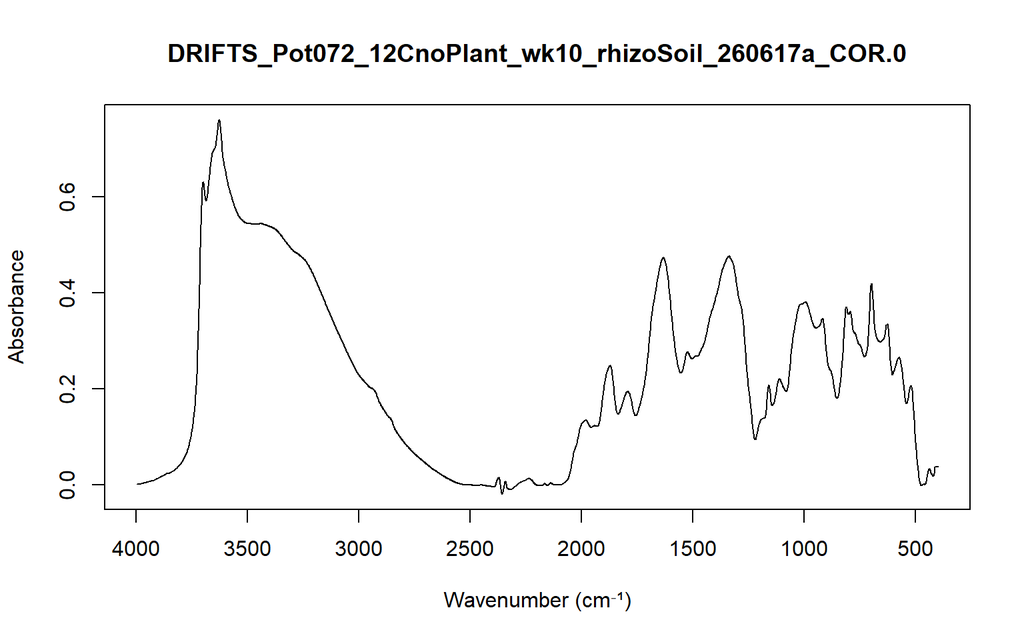

Metadata

| Parameter | Value |
| --- | --- |
| File Name | DRIFTS_Pot072_12CnoPlant_wk10_rhizoSoil_260617a_COR.0 |
| Timestamp | 2026-06-17 13:44:08 GMT-7 |
| Max Y | 0.759949803352356 |
| Min Y | -0.0194313321262598 |
| Aperture Setting | 4 mm |
| Scanner Velocity | 10.0S |
| Result Spectrum | AB |
| Resolution | 4 |
| Sample Scans | 400 |
| End Frequency | 400 |
| Start Frequency | 4000 |
| Duration | 364.48388671875 |
| Experiment (method) | SALK_soils_method.xpm |

#### Spectrum 32 : DRIFTS_Pot072_12CnoPlant_wk40_rhizoSoil_260617_COR.0

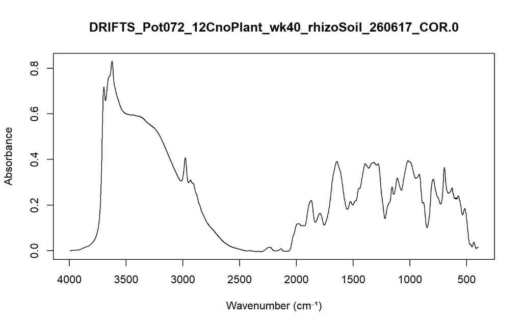

Metadata

| Parameter | Value |
| --- | --- |
| File Name | DRIFTS_Pot072_12CnoPlant_wk40_rhizoSoil_260617_COR.0 |
| Timestamp | 2026-06-17 13:44:21 GMT-7 |
| Max Y | 0.831821084022522 |
| Min Y | -0.00449259346351027 |
| Aperture Setting | 4 mm |
| Scanner Velocity | 10.0S |
| Result Spectrum | AB |
| Resolution | 4 |
| Sample Scans | 400 |
| End Frequency | 400 |
| Start Frequency | 4000 |
| Duration | 364.495849609375 |
| Experiment (method) | SALK_soils_method.xpm |

#### Spectrum 33 : DRIFTS_Pot080_13Csoy_wk10_rhizoSoil_260624_COR.0

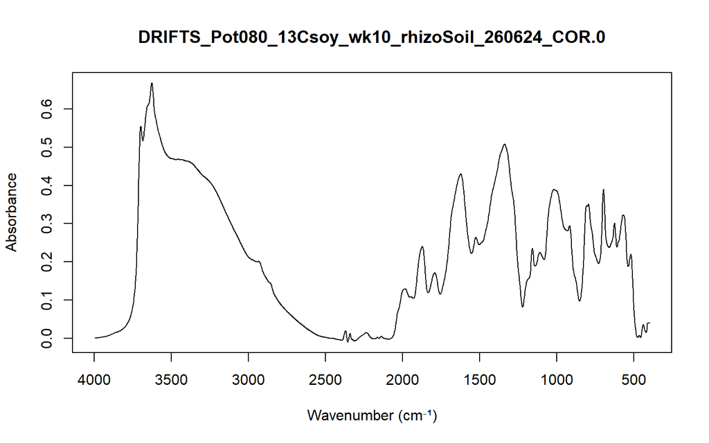

Metadata

| Parameter | Value |
| --- | --- |
| File Name | DRIFTS_Pot080_13Csoy_wk10_rhizoSoil_260624_COR.0 |
| Timestamp | 2026-06-24 16:33:39 GMT-7 |
| Max Y | 0.667920529842377 |
| Min Y | -0.00966909248381853 |
| Aperture Setting | 4 mm |
| Scanner Velocity | 10.0S |
| Result Spectrum | AB |
| Resolution | 4 |
| Sample Scans | 400 |
| End Frequency | 400 |
| Start Frequency | 4000 |
| Duration | 364.490966796875 |
| Experiment (method) | SALK_soils_method.xpm |